# 如何分析因子

研究因子分析，增減修改因子，不再靠感覺 以下是 FinLab Package 提供的因子分析流程：

```
原始數據
    │
    ├─── 特徵工程 ────→ 因子特徵 (Features)
    │
    └─── 標籤工程 ────→ 超額報酬 (Labels)
                │
                ├─── calc_factor_return() ────→ 因子報酬
                │      │
                |      └── calc_centrality() ─→ 因子集中度
                │
                ├─── calc_shapley_values() ───→ 因子貢獻度
                │
                └─── calc_ic() ───────────────→ 因子相關性(IC)
```

1. 先產生特徵與標籤(features, labels)，特徵是因子，標籤是股票的超額報酬
2. 計算因子報酬: `calc_factor_return(features, labels)`
3. 計算因子擁擠度: `calc_centrality(factor_return, window)`
4. 計算因子貢獻度: `calc_shapley_values(features, labels)`
5. 計算因子相關性(IC): `calc_ic(features, labels)`
6. 計算因子相關性(RankIC): `calc_rank_ic(features, labels)`

## 範例策略

此策略是由非常基本的三個因子組成:

1. 市值
2. 營收
3. 動能

我們先來看此策略的績效:

```python
from finlab import data
from finlab.backtest import sim

marketcap = data.get('etl:market_value')
revenue = data.get('monthly_revenue:當月營收')
price = data.get('etl:adj_close')

cond1 = marketcap.rank(pct=True, axis=1) < 0.3
cond2 = (revenue.average(3) / revenue.average(12)).rank(pct=True, axis=1) > 0.7
cond3 = (price / price.shift(20)).rank(pct=True, axis=1) > 0.7

pos = cond1 & cond2 & cond3

report = sim(pos, resample='ME', upload=False)
report.creturn.plot()
```

[output not shown]

[output not shown]

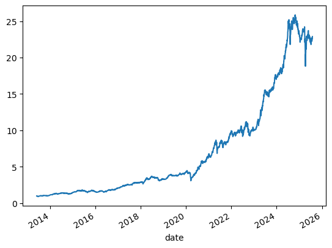

## 分析因子，先產生特徵與標籤

```python
from finlab import data
import finlab.ml.feature as feature
import finlab.ml.label as label

features =  feature.combine({
    'marketcap': cond1,
    'revenue': cond2,
    'momentum': cond3
}, resample='ME')

# 計算未來 1M 的標籤
labels = label.excess_over_mean(index=features.index, resample='ME')

features.dropna().head()
```

| datetime | instrument | marketcap | revenue | momentum |
| --- | --- | --- | --- | --- |
| 2013-04-30 | 1101 | False | True | True |
|  | 1102 | False | True | True |
|  | 1103 | False | True | False |
|  | 1104 | False | True | False |
|  | 1108 | False | True | False |

```python
labels.dropna().head()
```

```
datetime    instrument
2007-04-30  1101          0.042548
            1102          0.081764
            1103         -0.016863
            1104         -0.047492
            1108         -0.002247
dtype: float64
```

## 因子報酬（Factor Return）介紹

因子報酬（Factor Return）是衡量某因子在一段時間內所帶來超額報酬的指標，常用於評估因子的有效性與投資價值。

在本分析流程中，會先根據不同的因子（如市值、營收成長、動能等）建立特徵，並計算每個因子的因子報酬。透過累積因子報酬的走勢，可以觀察該因子的長期表現與穩定性，進一步作為因子篩選與組合的重要依據。

下方將以圖表方式展示各因子的累積報酬表現。

```python
from finlab.tools.factor_analysis import calc_factor_return
from finlab.plot import plot_line

plot_line(calc_factor_return(features, labels).cumsum(), unit='.0%', title='Factor Cumulative Return')
```

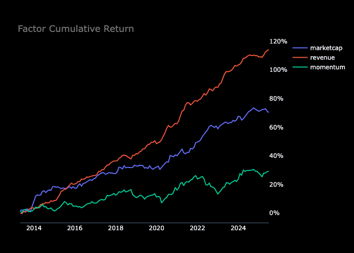

## 因子集中度（Factor Centrality）介紹

因子集中度（Factor Centrality），是用來量化「共同性」的指標。

因子集中度（Centrality）定義如下：

$$ \text{Centrality}_i = \frac{\lambda_i}{ \sum_{j=1}^{k}\lambda_j} $$

其中，$\lambda_j$ 為因子對於第一主成分的佔比，$k$ 為因子總數。

此指標反映了因子報酬的共同性，

- 數值越大表示
  - 利用此因子選股，在近期績效比較好。
  - 集中度越高，近而增加未來回檔的風險，需密切觀察。
- 數值越小表示
  - 利用此因子選股，在近期績效較差。
  - 集中度越低，未來回檔的風險較低。
  - 可以在因子擁擠度較低的時候，密切觀察，等擁擠度上升時，馬上利用此因子選股。

```python
from finlab.tools.factor_analysis import calc_centrality



plot_line(calc_centrality(calc_factor_return(features, labels), 12), title='Centrality')
```

```
Rolling Centrality: 148it [00:00, 733.93it/s]
```

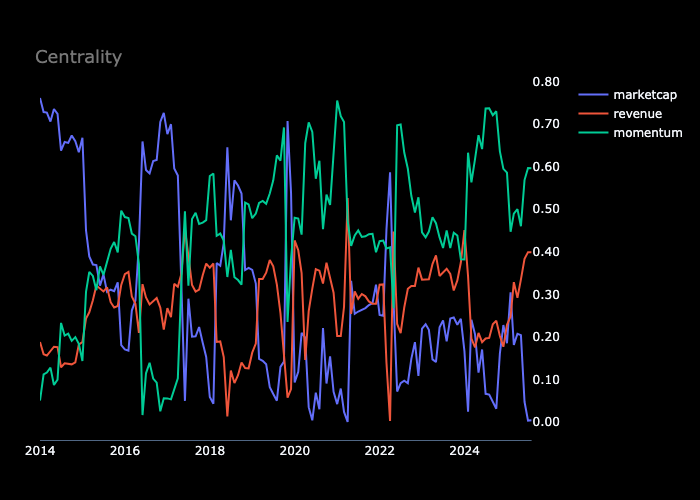

上圖中，當市值因子目前擁擠度較低，可以換一個因子，讓策略更穩定。

另外，也可以密切觀察市值因子，等擁擠度上升時，馬上利用此因子選股。

## Shapley Values

Shapley Values 是一種用於量化各個因子對投資組合報酬的貢獻度，是一種公平分配的數學方法。

我們枚舉所有可能的因子組合，計算每個因子組合的報酬，並計算每個因子對報酬的貢獻度。

我們甚至可以計算出，每個因子、每個時間點，對報酬的貢獻度。

值得一提的是，Shapley Values 的計算時間複雜度為 $O(2^n)$，其中 $n$ 為因子個數，因此計算時間較長，在因子個數較多時，建議使用其他方法。

```python
from finlab.tools.factor_analysis import calc_shapley_values


plot_line(calc_shapley_values(features, labels))
```

```
WARNING	finlab.tools.factor_analysis:factor_analysis.py:calc_shapley_values()- Feature and label date indices do not match exactly
```

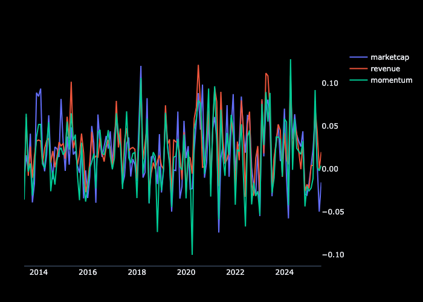

## 因子 IC（Information Coefficient）介紹

因子 IC（Information Coefficient）是衡量因子預測能力的重要指標，常用於評估因子與未來報酬之間的相關性。

IC 的計算公式如下：

$$ IC = \text{corr}(\text{Factor Score}, \text{Future Return}) $$

其中，$\text{corr}$ 表示相關係數（通常為皮爾森相關），$\text{Factor Score}$ 為因子分數，$\text{Future Return}$ 為未來一段期間的資產報酬。

IC 數值範圍通常在 -1 到 1 之間：

- IC 越接近 1，表示因子對未來報酬有很強的正向預測能力。
- IC 越接近 -1，表示因子對未來報酬有很強的反向預測能力。
- IC 接近 0，表示因子對未來報酬幾乎沒有預測能力。

在量化選股中，IC 是判斷因子有效性的重要依據，IC 越高的因子通常更值得納入投資組合。

```python
from finlab.tools.factor_analysis import calc_ic

features =  feature.combine({
    'marketcap': -marketcap, # 小市值
    'revenue': revenue.average(3) / revenue.average(12),
    'momentum': price / price.shift(20)
}, resample='ME')

plot_line(calc_ic(features, labels, rank=True))
```

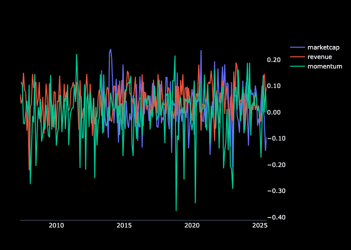